# Project1

ME

07/06/2022

I begin by loading the project-related dataset and examining the first rows

```r
wd <- "C:/Users/Amos.Turin/OneDrive - Essex County Council/Documents/Learning/R/Reproducible Project 1"
setwd(wd)

df <- read.csv("activity.csv")

head(df)
```

```
##   steps       date interval
## 1    NA 2012-10-01        0
## 2    NA 2012-10-01        5
## 3    NA 2012-10-01       10
## 4    NA 2012-10-01       15
## 5    NA 2012-10-01       20
## 6    NA 2012-10-01       25
```

## What is mean total number of steps taken per day?

Calculating the total number of steps taken per day

```r
df$date <- as.Date(as.character(df$date), "%Y-%m-%d")
daily_steps <- aggregate(df["steps"], by=df["date"], sum)
head(daily_steps)
```

```
##         date steps
## 1 2012-10-01    NA
## 2 2012-10-02   126
## 3 2012-10-03 11352
## 4 2012-10-04 12116
## 5 2012-10-05 13294
## 6 2012-10-06 15420
```

Plot the histogram of daily total steps

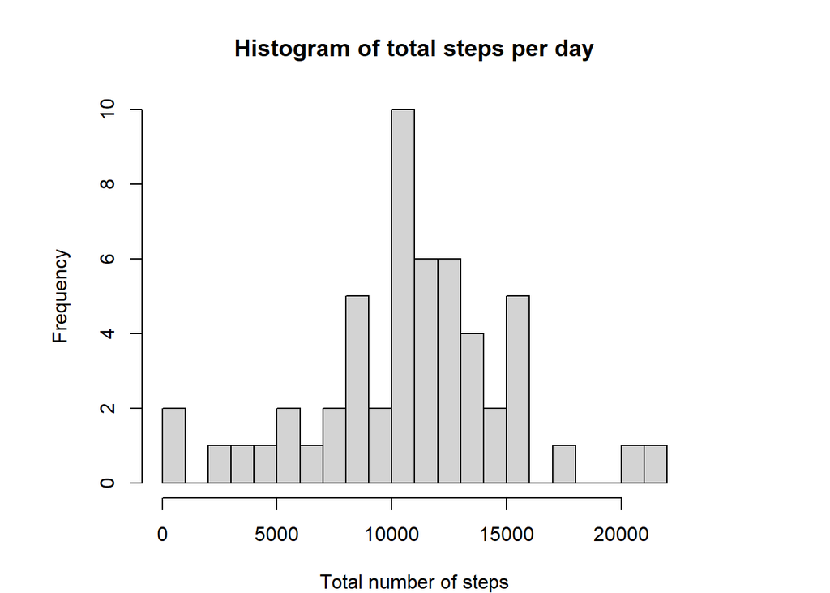

```r
par(mar=c(4,6,4,6))
hist(daily_steps$steps, breaks=20,
     xlab="Total number of steps",
     main="Histogram of total steps per day")
```

Finally, I calculate the mean and median values of total daily steps

```r
medSteps <- median(daily_steps$steps, na.rm=TRUE)
meanSteps <- mean(daily_steps$steps, na.rm=TRUE)

print(paste("Median: ", medSteps))
```

```
## [1] "Median:  10765"
```

```r
print(paste("Mean: ", round(meanSteps,2)))
```

```
## [1] "Mean:  10766.19"
```

## What is the average daily activity pattern?

I calculate the average number of steps for each 5-minute interval over all dates in the dataset. Then I plot the timeseries of intervals.

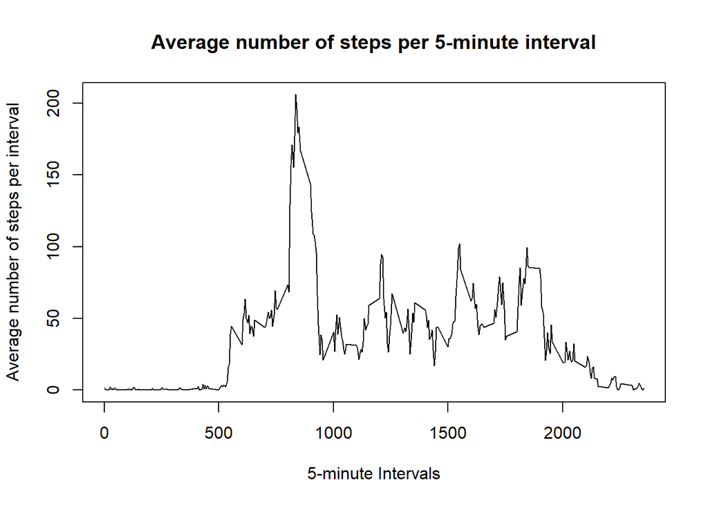

```r
df1 <- df[-which(is.na(df$steps)),]
interval_means <- aggregate(df1["steps"], by=df1["interval"], mean)

plot(interval_means$interval, interval_means$steps,
     type='l',
     xlab = "5-minute Intervals",
     ylab = "Average number of steps per interval",
     main = "Average number of steps per 5-minute interval")
```

From the plot it appears that the highest average number of steps in a 5-minute interval is in one of the intervals between 800-900 minutes.

Let’s confirm what the maximum is and its relevant interval

```r
interval_means[which.max(interval_means$steps),]
```

```
##     interval    steps
## 104      835 206.1698
```

The highest number of average steps is in the 835 interval at 206.2 steps.

## Imputing missing values

Calculating the total number of rows with NAs

```r
print(paste("Total number of rows with NAs:", sum(is.na(df))))
```

```
## [1] "Total number of rows with NAs: 2304"
```

I can confirm this result by looking calling summary() on my dataframe.

This is indeed the number of rows with NAs, all of which are in the steps column.

```r
summary(df)
```

```
##      steps             date               interval
##  Min.   :  0.00   Min.   :2012-10-01   Min.   :   0.0
##  1st Qu.:  0.00   1st Qu.:2012-10-16   1st Qu.: 588.8
##  Median :  0.00   Median :2012-10-31   Median :1177.5
##  Mean   : 37.38   Mean   :2012-10-31   Mean   :1177.5
##  3rd Qu.: 12.00   3rd Qu.:2012-11-15   3rd Qu.:1766.2
##  Max.   :806.00   Max.   :2012-11-30   Max.   :2355.0
##  NA's   :2304
```

Imputing NAs with the mean of their relevant 5-minute interval

```r
options(warn=-1)
library(dplyr)
```

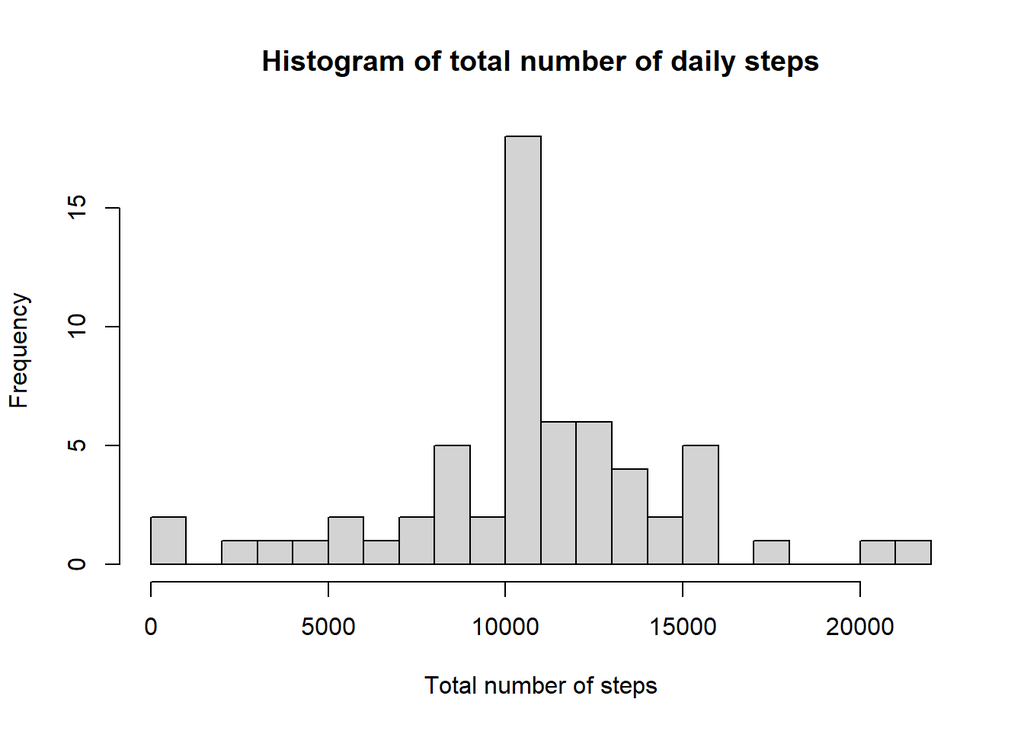

```r
new_df <- df %>%
      group_by(interval) %>%
      mutate_at("steps", function(x) replace(x, is.na(x), mean(x, na.rm=TRUE)))

new_daily_steps <- aggregate(new_df["steps"], by=new_df["date"], sum)

hist(new_daily_steps$steps,
     breaks=20,
     xlab = "Total number of steps",
     main = "Histogram of total number of daily steps")
```

What has happened to the Mean and Median number of total daily steps as a result of the missing value imputation?

As I have imputed using the mean values, the overall mean has not changed, and the median is now equal to the mean.

```r
newMedSteps <- median(new_daily_steps$steps, na.rm=TRUE)
newMeanSteps <- mean(new_daily_steps$steps, na.rm=TRUE)

print(paste("Median: ", round(newMedSteps,2)))
```

```
## [1] "Median:  10766.19"
```

```r
print(paste("Mean: ", round(newMeanSteps,2)))
```

```
## [1] "Mean:  10766.19"
```

## Are there differences in activity patterns between weekdays and weekends?

```r
options(warn=-1)
library(lubridate)
new_df <- new_df %>%
      mutate(weekday = wday(date, label=TRUE)) %>%
      mutate(weekday = ifelse(weekday == "Sun" | weekday == "Sat","Weekend","Weekday"))

new_df$weekday <- as.factor(new_df$weekday)
```

Plot the average steps per interval by Weekend vs Weekday

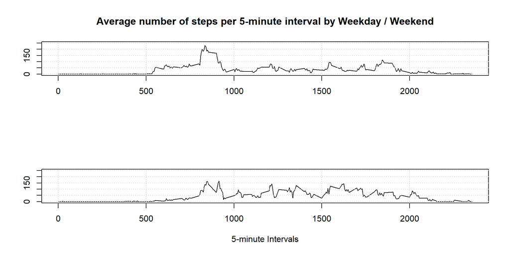

```r
wkdy <- subset(new_df, weekday == "Weekday")
wknd <- subset(new_df, weekday == "Weekend")
weekend_interval_means <- aggregate(wknd["steps"], by=wknd["interval"], mean)
weekday_interval_means <- aggregate(wkdy["steps"], by=wkdy["interval"], mean)

par(mfrow = c(2,1))
plot(weekday_interval_means$interval, weekday_interval_means$steps,
     type='l',
     ylab = "",
     xlab = "",
     ylim = c(0,250),
     main = "Average number of steps per 5-minute interval by Weekday / Weekend")
grid(NULL, NULL)
plot(weekend_interval_means$interval, weekend_interval_means$steps,
     type='l',
     ylab = "",
     ylim = c(0,250),
     xlab = "5-minute Intervals")
grid(NULL, NULL)
```